# A3: SPL Library Checkouts

### Introduction

The COVID-19 pandemic has significantly impacted various aspects of our lives, including how we interact with public spaces like libraries. In recent years, libraries have increasingly embraced digital technologies, allowing patrons to access a wide range of books and resources remotely. The Seattle Public Library is no exception, and its vast collection provides a valuable dataset for understanding the effects of the pandemic on book checkouts.I delve into the dataset of checkouts from the Seattle Public Library, specifically focusing on the period from 2017 to 2023. By examining the checkout trends over these years, we aim to identify relationships and effects that COVID-19 may have had on the library’s usage patterns, with a particular emphasis on checkout genres, usage class, and subjects.

### The Dataset

This data was collected and published by Seattle Public library itself. It was collected between 2017 to 2023, the number of checkouts is 816354, there are 61825 subjects of books.Firstly, the library management may collect this data for administrative purposes, helping them understand the popularity of different books, materials, and subjects to inform decisions on collection development and resource allocation. Secondly, the data may be collected for usage analysis, enabling insights into borrowing patterns, popular genres, and effectiveness of library services. Researchers or academic institutions may also collect this data to study reading habits, analyze trends, or investigate the impact of library services on communities. Lastly, the data can be utilized to support policy decisions and funding allocations by providing evidence of the library’s value and impact. Understanding the specific motivations behind the data collection would require insights from the organization responsible for collecting the data, such as the Seattle public library or the conducting research entity. The dataset on checkouts from the Seattle public library between 2017 and 2023 raises certain ethical questions that need consideration. Privacy is a paramount concern, as the dataset may contain personal information that should be protected. Proper anonymization techniques should be employed to safeguard individuals’ identities and comply with data protection regulations. Obtaining informed consent from library users for data collection and analysis is crucial, ensuring transparency and respect for their privacy rights. Additionally, understanding data ownership and adhering to usage restrictions set by the Seattle public library are essential ethical considerations. As with any dataset, there are potential limitations and problems to be aware of. The dataset’s representativeness may be a concern, as it may not encompass the entire population of library users or checkouts. This could impact the generalizability of findings. Data quality issues, such as missing or inaccurate information, could affect the reliability of analyses. Biases may be present, stemming from overrepresentation or underrepresentation of certain genres, subjects, or user demographics. External factors, such as changes in library policies or external events, should be taken into account when interpreting the data. Moreover, contextual information about individual checkouts may be lacking, limiting the depth of analysis and understanding of underlying motivations. Addressing these limitations and problems is crucial to ensure the ethical use and valid interpretation of the data

### First Trends Over Time Chart

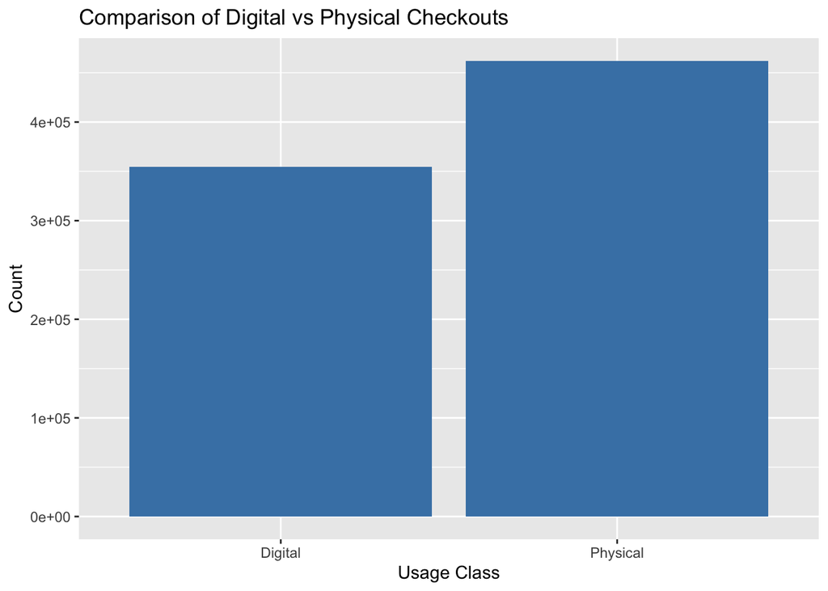

### Second Trends Over Time Chart

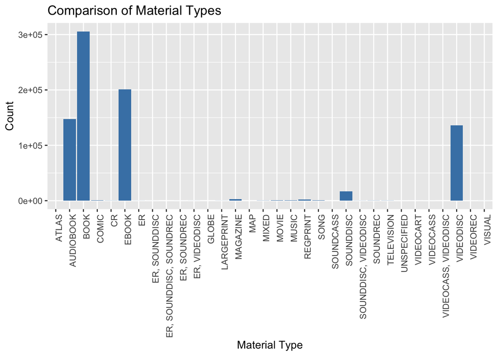

### Your Choice

-This graph is about my self-interest, as I like to borrow books from library too. I wanted to know what kind of books otr things people would like to borrow from the library and try them if I haven’t yet.TAmong the 5 different book that were mostly liked by people, the first one was headphones which people use it for various purposes, second one was the book “So you want to take about race”, I can see it that more people are getting engaged and putting effort learning more about race. Following these two stuffs, third one was the book “The house of broken angels”, next was also about race, last one followed as laptops which nowadays most people are tending to use them anywhere.

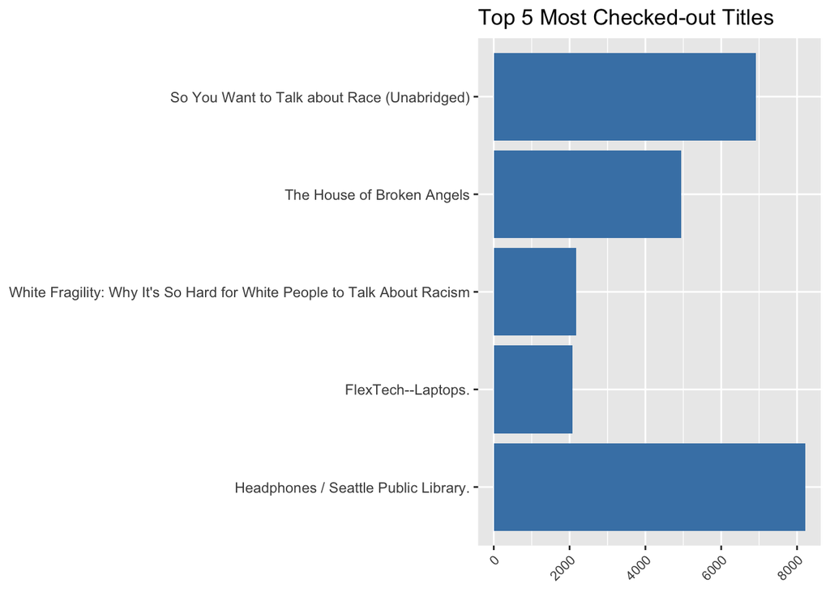